# Ingreso promedio per cápita

Lakner-Milanovic (2013)

Shiny App

Trabajaremos con la base Lakner-Milanovic (2013) para crear algunos gráficos sobre ingreso promedio per cápita (PPP 2005) durante el período 1988-2008.

Francisco Guzmán true  
04-19-2021

# Librerías

Cabe notar que al cargar *tidyverse* se cargan otros paquetes también. Se puede revisar en [click](https://www.tidyverse.org/packages/).

```r
library(haven)
library(tidyverse)
library(scales)
library(ggthemes)
library(gganimate)
library(plotly)
library(ggiraph)
library(Cairo)
```

# Base de Datos

## Obtención

Debemos ir a [Lakner-Milanovic (2013) World Panel Income Distribution (LM-WPID)](https://www.worldbank.org/en/research/brief/World-Panel-Income-Distribution) y descargar el archivo en formato *STATA (.dta)*.

## Importamos

Al estar en formato *.dta*, debemos usar el comando **read_dta** que nos otorga la librería **haven**.

```r
df <- read_dta("lm_wpid_web.dta")
attach(df)
```

## Visualización

```r
head(df)[c(1,8,9,11)]
```

```
# A tibble: 6 x 4
  contcod bin_year group RRinc
  <chr>      <dbl> <dbl> <dbl>
1 AGO         1993     1   174
2 AGO         1993     2   287
3 AGO         1993     3   373
4 AGO         1993     4   450
5 AGO         1993     5   538
6 AGO         1993     6   653
```

# Gráfico

- El comando **filter()** nos permite previamente seleccionar los países que queremos graficar.
- El operador [pipe](https://rsanchezs.gitbooks.io/rprogramming/content/chapter9/pipeline.html) **%>%** nos permite realizar múltiples operaciones.
- El comando **girafe()** nos permite agregar un *tooltip* haciendo más interactivo nuestro gráfico. Se debe agregar **geom_point_interactive()** previamente.

```r
g1 <- df %>%

  filter(contcod %in% c("CHL", "ESP")) %>%

  ggplot(aes(x = group, y = RRinc, color = contcod)) +
  geom_point_interactive(aes(tooltip = RRinc)) +
                           geom_line() +
  labs(title = "Ingreso promedio per cápita por decil (PPP 2005)",
       subtitle = "Chile vs España, período 1988-2008",
       caption = "Fuente: Elaboracion propia en base a Lakner-Milanovic (2013)",
       x = "Deciles",
       y = "USD - PPP 2005",
       col = NULL) +
       scale_color_manual(values = c("#DA0000", "#C4961A")) +
       scale_x_continuous(breaks=seq(1,10, by = 1), position = "bottom") +
       scale_y_continuous(labels = dollar) +
       facet_wrap(~bin_year, ncol = 3) +
  theme(plot.title = element_text(size = rel(2)),
        plot.subtitle = element_text(size = rel(1.4),
                                     margin=margin(0,0,20,0)),
        plot.caption = element_text(size = rel(.9),
                                    hjust = 0,
                                    face= "italic",
                                    margin=margin(20,0,0,0)),
        axis.text.x = element_text(angle = 0, vjust=.5, size = 10),
        axis.text.y = element_text(angle = 0, vjust=.5, size = 10),
        axis.ticks.length.x = unit(.2, "cm"),
        axis.ticks.x = element_line(size = .3),
        axis.ticks.length.y = unit(.2, "cm"),
        axis.ticks.y = element_line(size = .3),
        panel.grid.major.x = element_line(colour = "grey87"),
        panel.grid.minor.x = element_line(colour = "grey92"),
        panel.grid.major.y = element_line(colour = "grey87"),
        panel.grid.minor.y = element_line(colour = "grey87"),
        legend.position = c(0.87, 0.22),
        legend.text = element_text(size = 13),
        legend.key.size = unit(3,"line"))

girafe(ggobj = g1, width_svg = 8, height_svg = 6)
```

[interactive chart not shown]

## Guardar

```r
# Para guardar en formato png
ggsave(g1, filename = "plot.png", type = 'cairo', dpi = 300,
       width = 8, height = 6)

# Para guardar con más calidad (pdf o eps)
ggsave(g1, filename = "plot.pdf", device = cairo_pdf, dpi = 300,
       width = 8, height = 6)

ggsave(g1, filename = "plot.eps", device = cairo_ps, dpi = 300,
       width = 8, height = 6)
```

# Más Gráficos

## Chile vs Portugal

```r
g2 <- df %>%

  filter(contcod %in% c("CHL", "PRT")) %>%

  ggplot(aes(x = group, y = RRinc, color = contcod)) +
  geom_point_interactive(aes(tooltip = RRinc)) +
                           geom_line() +
  labs(title = "Ingreso promedio per cápita por decil (PPP 2005)",
       subtitle = "Chile vs Portugal, período 1988-2008",
       caption = "Fuente: Elaboracion propia en base a Lakner-Milanovic (2013)",
       x = "Deciles",
       y = "USD - PPP 2005",
       col = NULL) +
       scale_color_manual(values = c("#DA0000", "#239f40")) +
       scale_x_continuous(breaks=seq(1,10, by = 1), position = "bottom") +
       scale_y_continuous(labels = dollar, limits = c(0, 30000)) +
       facet_wrap(~bin_year, ncol = 3) +
  theme(plot.title = element_text(size = rel(2)),
        plot.subtitle = element_text(size = rel(1.4),
                                     margin=margin(0,0,20,0)),
        plot.caption = element_text(size = rel(.9),
                                    hjust = 0,
                                    face= "italic",
                                    margin=margin(20,0,0,0)),
        axis.text.x = element_text(angle = 0, vjust=.5, size = 10),
        axis.text.y = element_text(angle = 0, vjust=.5, size = 10),
        axis.ticks.length.x = unit(.2, "cm"),
        axis.ticks.x = element_line(size = .3),
        axis.ticks.length.y = unit(.2, "cm"),
        axis.ticks.y = element_line(size = .3),
        panel.grid.major.x = element_line(colour = "grey87"),
        panel.grid.minor.x = element_line(colour = "grey92"),
        panel.grid.major.y = element_line(colour = "grey87"),
        panel.grid.minor.y = element_line(colour = "grey87"),
        legend.position = c(0.87, 0.22),
        legend.text = element_text(size = 13),
        legend.key.size = unit(3,"line"))

girafe(ggobj = g2, width_svg = 8, height_svg = 6)
```

[interactive chart not shown]

## Chile vs Suecia

No hay datos para Suecia 1988.

```r
g3 <- df %>%

  filter(contcod %in% c("CHL", "SWE")) %>%

  ggplot(aes(x = group, y = RRinc, color = contcod)) +
  geom_point_interactive(aes(tooltip = RRinc)) +
                           geom_line() +
  labs(title = "Ingreso promedio per cápita por decil (PPP 2005)",
       subtitle = "Chile vs Suecia, período 1988-2008",
       caption = "Fuente: Elaboracion propia en base a Lakner-Milanovic (2013)",
       x = "Deciles",
       y = "USD - PPP 2005",
       col = NULL) +
       scale_color_manual(values = c("#DA0000", "#293352")) +
       scale_x_continuous(breaks=seq(1,10, by = 1), position = "bottom") +
       scale_y_continuous(labels = dollar) +
       facet_wrap(~bin_year, ncol = 3) +
  theme(plot.title = element_text(size = rel(2)),
        plot.subtitle = element_text(size = rel(1.4),
                                     margin=margin(0,0,20,0)),
        plot.caption = element_text(size = rel(.9),
                                    hjust = 0,
                                    face= "italic",
                                    margin=margin(20,0,0,0)),
        axis.text.x = element_text(angle = 0, vjust=.5, size = 10),
        axis.text.y = element_text(angle = 0, vjust=.5, size = 10),
        axis.ticks.length.x = unit(.2, "cm"),
        axis.ticks.x = element_line(size = .3),
        axis.ticks.length.y = unit(.2, "cm"),
        axis.ticks.y = element_line(size = .3),
        panel.grid.major.x = element_line(colour = "grey87"),
        panel.grid.minor.x = element_line(colour = "grey92"),
        panel.grid.major.y = element_line(colour = "grey87"),
        panel.grid.minor.y = element_line(colour = "grey87"),
        legend.position = c(0.87, 0.22),
        legend.text = element_text(size = 13),
        legend.key.size = unit(3,"line"))

girafe(ggobj = g3, width_svg = 8, height_svg = 6)
```

[interactive chart not shown]

## Chile vs Holanda

```r
g4 <- df %>%

  filter(contcod %in% c("CHL", "NLD")) %>%

  ggplot(aes(x = group, y = RRinc, color = contcod)) +
  geom_point_interactive(aes(tooltip = RRinc)) +
                           geom_line() +
  labs(title = "Ingreso promedio per cápita por decil (PPP 2005)",
       subtitle = "Chile vs Holanda, período 1988-2008",
       caption = "Fuente: Elaboracion propia en base a Lakner-Milanovic (2013)",
       x = "Deciles",
       y = "USD - PPP 2005",
       col = NULL) +
       scale_color_manual(values = c("#DA0000", "#f37735")) +
       scale_x_continuous(breaks=seq(1,10, by = 1), position = "bottom") +
       scale_y_continuous(labels = dollar, limits = c(0, 40000)) +
       facet_wrap(~bin_year, ncol = 3) +
  theme(plot.title = element_text(size = rel(2)),
        plot.subtitle = element_text(size = rel(1.4),
                                     margin=margin(0,0,20,0)),
        plot.caption = element_text(size = rel(.9),
                                    hjust = 0,
                                    face= "italic",
                                    margin=margin(20,0,0,0)),
        axis.text.x = element_text(angle = 0, vjust=.5, size = 10),
        axis.text.y = element_text(angle = 0, vjust=.5, size = 10),
        axis.ticks.length.x = unit(.2, "cm"),
        axis.ticks.x = element_line(size = .3),
        axis.ticks.length.y = unit(.2, "cm"),
        axis.ticks.y = element_line(size = .3),
        panel.grid.major.x = element_line(colour = "grey87"),
        panel.grid.minor.x = element_line(colour = "grey92"),
        panel.grid.major.y = element_line(colour = "grey87"),
        panel.grid.minor.y = element_line(colour = "grey87"),
        legend.position = c(0.87, 0.22),
        legend.text = element_text(size = 13),
        legend.key.size = unit(3,"line"))

girafe(ggobj = g4, width_svg = 8, height_svg = 6)
```

[interactive chart not shown]

## Chile vs España y Bolivia

```r
g5 <- df %>%

  filter(contcod %in% c("CHL", "ESP", "BOL")) %>%

  ggplot(aes(x = group, y = RRinc, color = contcod)) +
  geom_point_interactive(aes(tooltip = RRinc)) +
                           geom_line() +
  labs(title = "Ingreso promedio per cápita por decil (PPP 2005)",
       subtitle = "Chile vs España y Bolivia, período 1988-2008",
       caption = "Fuente: Elaboracion propia en base a Lakner-Milanovic (2013)",
       x = "Deciles",
       y = "USD - PPP 2005",
       col = NULL) +
       scale_color_manual(values = c("#239f40", "#DA0000", "#C4961A")) +
       scale_x_continuous(breaks=seq(1,10, by = 1), position = "bottom") +
       scale_y_continuous(labels = dollar, limits = c(0, 30000)) +
       facet_wrap(~bin_year, ncol = 3) +
  theme(plot.title = element_text(size = rel(2)),
        plot.subtitle = element_text(size = rel(1.4),
                                     margin=margin(0,0,20,0)),
        plot.caption = element_text(size = rel(.9),
                                    hjust = 0,
                                    face= "italic",
                                    margin=margin(20,0,0,0)),
        axis.text.x = element_text(angle = 0, vjust=.5, size = 10),
        axis.text.y = element_text(angle = 0, vjust=.5, size = 10),
        axis.ticks.length.x = unit(.2, "cm"),
        axis.ticks.x = element_line(size = .3),
        axis.ticks.length.y = unit(.2, "cm"),
        axis.ticks.y = element_line(size = .3),
        panel.grid.major.x = element_line(colour = "grey87"),
        panel.grid.minor.x = element_line(colour = "grey92"),
        panel.grid.major.y = element_line(colour = "grey87"),
        panel.grid.minor.y = element_line(colour = "grey87"),
        legend.position = c(0.87, 0.22),
        legend.text = element_text(size = 13),
        legend.key.size = unit(3,"line"))

girafe(ggobj = g5, width_svg = 8, height_svg = 6)
```

[interactive chart not shown]

# Gráfico Interactivo

- Se debe acceder al siguiente link **[Shiny App](https://panchoguzman.shinyapps.io/Ingreso_promedio_pc_ppp_2005/)**.

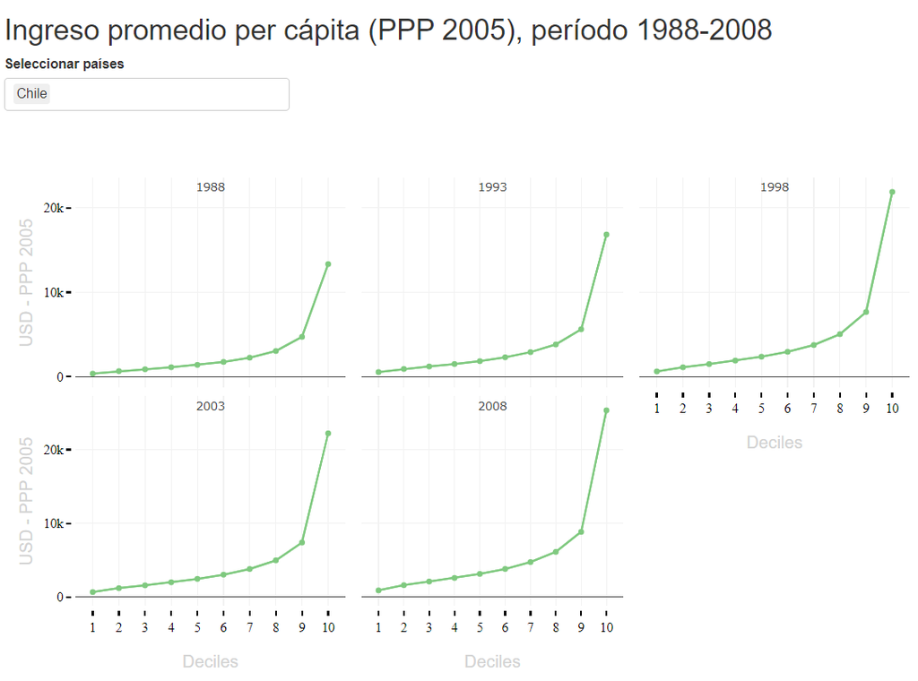

# Código

```r
library(haven)
library(tidyverse)
library(scales)
library(ggthemes)
library(gganimate)
library(plotly)
library(ggiraph)
library(Cairo)

df <- read_dta("lm_wpid_web.dta")
attach(df)

head(df)[c(1,8,9,11)]

g1 <- df %>%

  filter(contcod %in% c("CHL", "ESP")) %>%

  ggplot(aes(x = group, y = RRinc, color = contcod)) +
  geom_point_interactive(aes(tooltip = RRinc)) +
                           geom_line() +
  labs(title = "Ingreso promedio per cápita por decil (PPP 2005)",
       subtitle = "Chile vs España, período 1988-2008",
       caption = "Fuente: Elaboracion propia en base a Lakner-Milanovic (2013)",
       x = "Deciles",
       y = "USD - PPP 2005",
       col = NULL) +
       scale_color_manual(values = c("#DA0000", "#C4961A")) +
       scale_x_continuous(breaks=seq(1,10, by = 1), position = "bottom") +
       scale_y_continuous(labels = dollar) +
       facet_wrap(~bin_year, ncol = 3) +
  theme(plot.title = element_text(size = rel(2)),
        plot.subtitle = element_text(size = rel(1.4),
                                     margin=margin(0,0,20,0)),
        plot.caption = element_text(size = rel(.9),
                                    hjust = 0,
                                    face= "italic",
                                    margin=margin(20,0,0,0)),
        axis.text.x = element_text(angle = 0, vjust=.5, size = 10),
        axis.text.y = element_text(angle = 0, vjust=.5, size = 10),
        axis.ticks.length.x = unit(.2, "cm"),
        axis.ticks.x = element_line(size = .3),
        axis.ticks.length.y = unit(.2, "cm"),
        axis.ticks.y = element_line(size = .3),
        panel.grid.major.x = element_line(colour = "grey87"),
        panel.grid.minor.x = element_line(colour = "grey92"),
        panel.grid.major.y = element_line(colour = "grey87"),
        panel.grid.minor.y = element_line(colour = "grey87"),
        legend.position = c(0.87, 0.22),
        legend.text = element_text(size = 13),
        legend.key.size = unit(3,"line"))

girafe(ggobj = g1, width_svg = 8, height_svg = 6)

# Para guardar en formato png
ggsave(g1, filename = "plot.png", type = 'cairo', dpi = 300,
       width = 8, height = 6)

# Para guardar con más calidad (pdf o eps)
ggsave(g1, filename = "plot.pdf", device = cairo_pdf, dpi = 300,
       width = 8, height = 6)

ggsave(g1, filename = "plot.eps", device = cairo_ps, dpi = 300,
       width = 8, height = 6)
g2 <- df %>%

  filter(contcod %in% c("CHL", "PRT")) %>%

  ggplot(aes(x = group, y = RRinc, color = contcod)) +
  geom_point_interactive(aes(tooltip = RRinc)) +
                           geom_line() +
  labs(title = "Ingreso promedio per cápita por decil (PPP 2005)",
       subtitle = "Chile vs Portugal, período 1988-2008",
       caption = "Fuente: Elaboracion propia en base a Lakner-Milanovic (2013)",
       x = "Deciles",
       y = "USD - PPP 2005",
       col = NULL) +
       scale_color_manual(values = c("#DA0000", "#239f40")) +
       scale_x_continuous(breaks=seq(1,10, by = 1), position = "bottom") +
       scale_y_continuous(labels = dollar, limits = c(0, 30000)) +
       facet_wrap(~bin_year, ncol = 3) +
  theme(plot.title = element_text(size = rel(2)),
        plot.subtitle = element_text(size = rel(1.4),
                                     margin=margin(0,0,20,0)),
        plot.caption = element_text(size = rel(.9),
                                    hjust = 0,
                                    face= "italic",
                                    margin=margin(20,0,0,0)),
        axis.text.x = element_text(angle = 0, vjust=.5, size = 10),
        axis.text.y = element_text(angle = 0, vjust=.5, size = 10),
        axis.ticks.length.x = unit(.2, "cm"),
        axis.ticks.x = element_line(size = .3),
        axis.ticks.length.y = unit(.2, "cm"),
        axis.ticks.y = element_line(size = .3),
        panel.grid.major.x = element_line(colour = "grey87"),
        panel.grid.minor.x = element_line(colour = "grey92"),
        panel.grid.major.y = element_line(colour = "grey87"),
        panel.grid.minor.y = element_line(colour = "grey87"),
        legend.position = c(0.87, 0.22),
        legend.text = element_text(size = 13),
        legend.key.size = unit(3,"line"))

girafe(ggobj = g2, width_svg = 8, height_svg = 6)

g3 <- df %>%

  filter(contcod %in% c("CHL", "SWE")) %>%

  ggplot(aes(x = group, y = RRinc, color = contcod)) +
  geom_point_interactive(aes(tooltip = RRinc)) +
                           geom_line() +
  labs(title = "Ingreso promedio per cápita por decil (PPP 2005)",
       subtitle = "Chile vs Suecia, período 1988-2008",
       caption = "Fuente: Elaboracion propia en base a Lakner-Milanovic (2013)",
       x = "Deciles",
       y = "USD - PPP 2005",
       col = NULL) +
       scale_color_manual(values = c("#DA0000", "#293352")) +
       scale_x_continuous(breaks=seq(1,10, by = 1), position = "bottom") +
       scale_y_continuous(labels = dollar) +
       facet_wrap(~bin_year, ncol = 3) +
  theme(plot.title = element_text(size = rel(2)),
        plot.subtitle = element_text(size = rel(1.4),
                                     margin=margin(0,0,20,0)),
        plot.caption = element_text(size = rel(.9),
                                    hjust = 0,
                                    face= "italic",
                                    margin=margin(20,0,0,0)),
        axis.text.x = element_text(angle = 0, vjust=.5, size = 10),
        axis.text.y = element_text(angle = 0, vjust=.5, size = 10),
        axis.ticks.length.x = unit(.2, "cm"),
        axis.ticks.x = element_line(size = .3),
        axis.ticks.length.y = unit(.2, "cm"),
        axis.ticks.y = element_line(size = .3),
        panel.grid.major.x = element_line(colour = "grey87"),
        panel.grid.minor.x = element_line(colour = "grey92"),
        panel.grid.major.y = element_line(colour = "grey87"),
        panel.grid.minor.y = element_line(colour = "grey87"),
        legend.position = c(0.87, 0.22),
        legend.text = element_text(size = 13),
        legend.key.size = unit(3,"line"))

girafe(ggobj = g3, width_svg = 8, height_svg = 6)

g4 <- df %>%

  filter(contcod %in% c("CHL", "NLD")) %>%

  ggplot(aes(x = group, y = RRinc, color = contcod)) +
  geom_point_interactive(aes(tooltip = RRinc)) +
                           geom_line() +
  labs(title = "Ingreso promedio per cápita por decil (PPP 2005)",
       subtitle = "Chile vs Holanda, período 1988-2008",
       caption = "Fuente: Elaboracion propia en base a Lakner-Milanovic (2013)",
       x = "Deciles",
       y = "USD - PPP 2005",
       col = NULL) +
       scale_color_manual(values = c("#DA0000", "#f37735")) +
       scale_x_continuous(breaks=seq(1,10, by = 1), position = "bottom") +
       scale_y_continuous(labels = dollar, limits = c(0, 40000)) +
       facet_wrap(~bin_year, ncol = 3) +
  theme(plot.title = element_text(size = rel(2)),
        plot.subtitle = element_text(size = rel(1.4),
                                     margin=margin(0,0,20,0)),
        plot.caption = element_text(size = rel(.9),
                                    hjust = 0,
                                    face= "italic",
                                    margin=margin(20,0,0,0)),
        axis.text.x = element_text(angle = 0, vjust=.5, size = 10),
        axis.text.y = element_text(angle = 0, vjust=.5, size = 10),
        axis.ticks.length.x = unit(.2, "cm"),
        axis.ticks.x = element_line(size = .3),
        axis.ticks.length.y = unit(.2, "cm"),
        axis.ticks.y = element_line(size = .3),
        panel.grid.major.x = element_line(colour = "grey87"),
        panel.grid.minor.x = element_line(colour = "grey92"),
        panel.grid.major.y = element_line(colour = "grey87"),
        panel.grid.minor.y = element_line(colour = "grey87"),
        legend.position = c(0.87, 0.22),
        legend.text = element_text(size = 13),
        legend.key.size = unit(3,"line"))

girafe(ggobj = g4, width_svg = 8, height_svg = 6)

g5 <- df %>%

  filter(contcod %in% c("CHL", "ESP", "BOL")) %>%

  ggplot(aes(x = group, y = RRinc, color = contcod)) +
  geom_point_interactive(aes(tooltip = RRinc)) +
                           geom_line() +
  labs(title = "Ingreso promedio per cápita por decil (PPP 2005)",
       subtitle = "Chile vs España y Bolivia, período 1988-2008",
       caption = "Fuente: Elaboracion propia en base a Lakner-Milanovic (2013)",
       x = "Deciles",
       y = "USD - PPP 2005",
       col = NULL) +
       scale_color_manual(values = c("#239f40", "#DA0000", "#C4961A")) +
       scale_x_continuous(breaks=seq(1,10, by = 1), position = "bottom") +
       scale_y_continuous(labels = dollar, limits = c(0, 30000)) +
       facet_wrap(~bin_year, ncol = 3) +
  theme(plot.title = element_text(size = rel(2)),
        plot.subtitle = element_text(size = rel(1.4),
                                     margin=margin(0,0,20,0)),
        plot.caption = element_text(size = rel(.9),
                                    hjust = 0,
                                    face= "italic",
                                    margin=margin(20,0,0,0)),
        axis.text.x = element_text(angle = 0, vjust=.5, size = 10),
        axis.text.y = element_text(angle = 0, vjust=.5, size = 10),
        axis.ticks.length.x = unit(.2, "cm"),
        axis.ticks.x = element_line(size = .3),
        axis.ticks.length.y = unit(.2, "cm"),
        axis.ticks.y = element_line(size = .3),
        panel.grid.major.x = element_line(colour = "grey87"),
        panel.grid.minor.x = element_line(colour = "grey92"),
        panel.grid.major.y = element_line(colour = "grey87"),
        panel.grid.minor.y = element_line(colour = "grey87"),
        legend.position = c(0.87, 0.22),
        legend.text = element_text(size = 13),
        legend.key.size = unit(3,"line"))

girafe(ggobj = g5, width_svg = 8, height_svg = 6)

knitr::include_graphics("captura.png")
```

# Referencias

- [Lakner-Milanovic (2013) World Panel Income Distribution (LM-WPID)](https://www.worldbank.org/en/research/brief/World-Panel-Income-Distribution)
- [Operador pipe](https://rsanchezs.gitbooks.io/rprogramming/content/chapter9/pipeline.html)
- [tidyverse](https://www.tidyverse.org/packages/)